# Nass TSA Netdown

G Nienaber

November 13, 2019

# 1 Netdown Resultant

A resultant was created specifically for the netdown process. The key `gr_skey` was maintained for returning the results and mapping with the Provincial grid.

The area within the TSA boundary was identified where the `gr_skey` values are positive. All areas outside of the TSA boundary were deleted to increase processing speed. The attribute `included` was added with a value of 1 for everywhere in the TSA to match the analysis ready data set format and simplify total area summaries.

```sql
drop table if exists tsa43_netdown;
create table tsa43_netdown as (
  select
    ogc_fid,
    gr_skey,
    feature_id,
    bclcs_lv_1,
    bclcs_lv_3,
    bclcs_lv_2,
    bclcs_lv_4,
    site_index,
    spec_cd_1,
    proj_age_1,
    np_desc,
    harvest_year,
    f_own_code own,
    f_own_schedule schedule,
    lu_name,
    bgc_label,
    ogma_provid,
    rec_type,
    zone_name,
    eca_thrshd,
    eco_network,
    eco_net_buffer,
    gen_wildlife,
    kwin_river,
    water_mu,
    uwr_noharvest,
    silv_polygon_no,
    wha_harv_code,
    sample_number,
    bordennumber,
    cws_name
  from tsa43_res
  where gr_skey > 0
);

alter table tsa43_netdown add column included int default 1;
```

The attributes for tracking Crown Forest Land Base (CFLB) and Timber Harvesting Land Base (THLB) were created. These are float values representing percent inclusion. The entire TSA is assumed 100% included by default to start. The two factors are used multiplicatively in the timber supply model so it is possible for THLB to be within the non-CFLB.

Attributes are also created for tracking each of the netdown factors. The full THLB exclusions are tracked using text attributes (starting with ‘n’) so descriptions of the exclusions can be recorded. Paritial exclusion netdown factors are tracked with numeric attributes (starting with ‘p’) for recording the percentage of each hectare within the THLB.

```sql
alter table tsa43_netdown
  add column cflb_fact numeric default 1.0,
  add column thlb_fact numeric default 1.0,
  add column thlb_net numeric default 1.0,
  add column n01_ownership text,
  add column n02_nonfor text,
  add column p03_road numeric default 1.0,
  add column n04_park text,
  add column n05_recsite text,
  add column n06_rectrail text,
  add column p06_rectrail numeric default 1.0,
  add column n07_inoperable text,
  add column n08_uppernass text,
  add column n09_lowsite text,
  add column n10_decid text,
  add column n11_ogma text,
  add column n12_econet text,
  add column p12_econet numeric default 1.0,
  add column n13_wtra text,
  add column n14_riparian text,
  add column p14_riparian numeric default 1.0,
  add column n15_watershed text,
  add column n16_wha text,
  add column n17_genwild text,
  add column n18_arch text,
  add column n19_psp text,
  add column n20_cws text,
  add column n21_uwr text,
  add column n22_pinemush text;
```

The traditional netdown summary table in the Data Package is structured in way that presents a sequential “area excluded”. This area excluded total differs from the total of (1-thlb_fact) in that it accounts for all prior netdown reductions as well. So an additional variable ‘thlb_net’ was created to track the sequential area removed to be reported in the netdown table.

```sql
drop table if exists tsa43_netdowntable;
create table tsa43_netdowntable (
    landclass text,
    total numeric,
    percent numeric,
    excluded numeric
);
```

# 2 Timber Supply Area Boundary

The area outside of the TSA boundary was excluded when the netdown table was created using the `included` attribute.

| Included | Total |
| --- | --- |
| Nass TSA | 1,711,705 |

## 2.1 Non-Provincial Crown Lands

The non-provincial crown lands were removed using the ownership layer. The attributes `own` and `schedule` were used but the schedule did not change for each ownership so it was not referenced in the script.

At this time it was found that the resultant included 2 ha classified as TFL even though no TFLs exist within the TSA. This was likely due to a silver of overlap with adjacent TFL 1. Since there are no area-based licence removals this was cleaned up at this stage to ensure all ownership codes are accounted.

No area came out under ownership code 52 Federal Indian Reserve. It was confirmed that no reserves exist in the TSA using the layer WHSE_ADMIN_BOUNDARIES.CLAB_INDIAN_RESERVES cited in the Data Package. The exclusion of the Nisga’a Treaty Land under ownership code 41 Land Claim Settlement Area was confirmed using the layer WHSE_LEGAL_ADMIN_BOUNDARIES.FNT_TREATY_LAND_SP cited in the Data Package.

After the following parks/protected area and the recreation netdown steps that also use the ownership attribute the only remaining ownership code in the THLB was 62 (Crown - Forest Management Unit) and some of 69 (Crown - Misc. Reserves ).

During the Data Package review, an error was found in the Recreation Sites and Trails section which used the ownership code to identify UREP reserves. The 2019 version of the ownership layer had this issue corrected so the netdown was updated to use this layer instead of the 2018 analysis ready version.

```sql
-- set nulls to 91 U - Unknown Ownership/Exceptions
update tsa43_netdown set
  own = coalesce(own,91),
  schedule = coalesce(schedule,'U');

update tsa43_netdown set
  n01_ownership = case
    when own = 40 then 'Private'
    when own = 80 then 'Municipal Parcels'
    when own = 54 then 'Federal Reserve'
    when own = 41 then 'Land Claim Settlement Area'
    when own = 52 then 'Federal Indian Reserve'
    when own = 72 then 'Tree Farm Licence'
    when own = 99 then 'Crown Lease'
    when own = 91 then 'Unknown Ownership/Exceptions'
  end;
```

| Ownership | Schedule | Description | Total |
| --- | --- | --- | --- |
| 40 | N | Private | 1,429 |
| 41 | N | Land Claim Settlement Area | 28,169 |
| 54 | N | Federal Reserve | 86 |
| 80 | N | Municipal Parcels | 179 |
| 91 | U | Unknown Ownership/Exceptions | 539 |
| 99 | U | Crown Lease | 64 |
| Total |  |  | 30,466 |

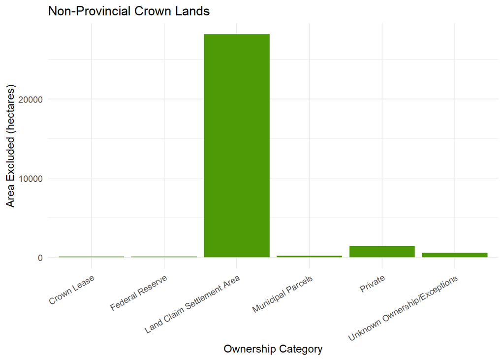

## 2.2 Not Managed Within TSA AAC

No removals were specified in the Data Package for this factor since no area-based tenures exist within the TSA. This was confirmed with the evaluation of the ownership codes above. Only a small overlap sliver with adjacent TFL 1 was found and removed.

When the Ownership layer was updated to 2019 the sliver of TFL 1 was fixed and is no longer present in the data.

## 2.3 Non-Forest and Non-Productive Forest

The non-forest areas were identified using the BC Land Classification System (BCLCS) provided by the VRI. The old FC1 non-productive attributes were also used as a secondary check.

After the Data Package was released the use of 3m as the site index cut off was questioned. No support of this historic value could be found in any land use plan or legislation. The value was increased to 5m to match the VRI FMLB criteria.

After the Data Package was released and harvest depletions were being run, it was discovered that a significant area was assigned a site index greater than 5m but no projected age was interpretted. This area covers 52,919ha but most was net out of the CFLB except for 9533ha. A comparison with the satellite imagery found that the 5488ha that passed through to be THLB was entirely open meadows with sparse trees. The largest areas were avalanche slides. This area was added to the non-productive netdown under the assumption that if insufficient trees were available to interpret an age then it will not be harvestable. Also avoids arbitrary assignment of age. Placed it at the end as a final catch since it overlaps with np_desc.

```sql
update tsa43_netdown set
  n02_nonfor = case
    when bclcs_lv_3 = 'A' then 'Alpine'
    when bclcs_lv_1 = 'N' then 'Non-Vegetated'
    when bclcs_lv_3 = 'W' then 'Wetlands'
    when bclcs_lv_2 = 'N' and bclcs_lv_4 not in ('ST', 'SL') then 'Non-Treed Herb'
    when bclcs_lv_4 in ('ST', 'SL') and harvest_year is null then 'Non-Treed Shrub'
    when (coalesce(site_index, 0) < 5) and harvest_year is null then 'Non-Productive'
    when np_desc is not null and harvest_year is null then 'FC1_' || np_desc
    when proj_age_1 is null and harvest_year is null then 'Sparse with No Age'
    when bclcs_lv_1 = 'U' or bclcs_lv_1 is null then 'Unclassified'
  end;
```

| Description | Total |
| --- | --- |
| Alpine | 853,296 |
| FC1_AF | 6,258 |
| FC1_NP | 2,493 |
| Non-Productive | 130,634 |
| Non-Treed Herb | 134 |
| Non-Treed Shrub | 86,913 |
| Non-Vegetated | 34,381 |
| Sparse with No Age | 7,818 |
| Unclassified | 124 |
| Wetlands | 13,597 |
| Total | 1,135,648 |

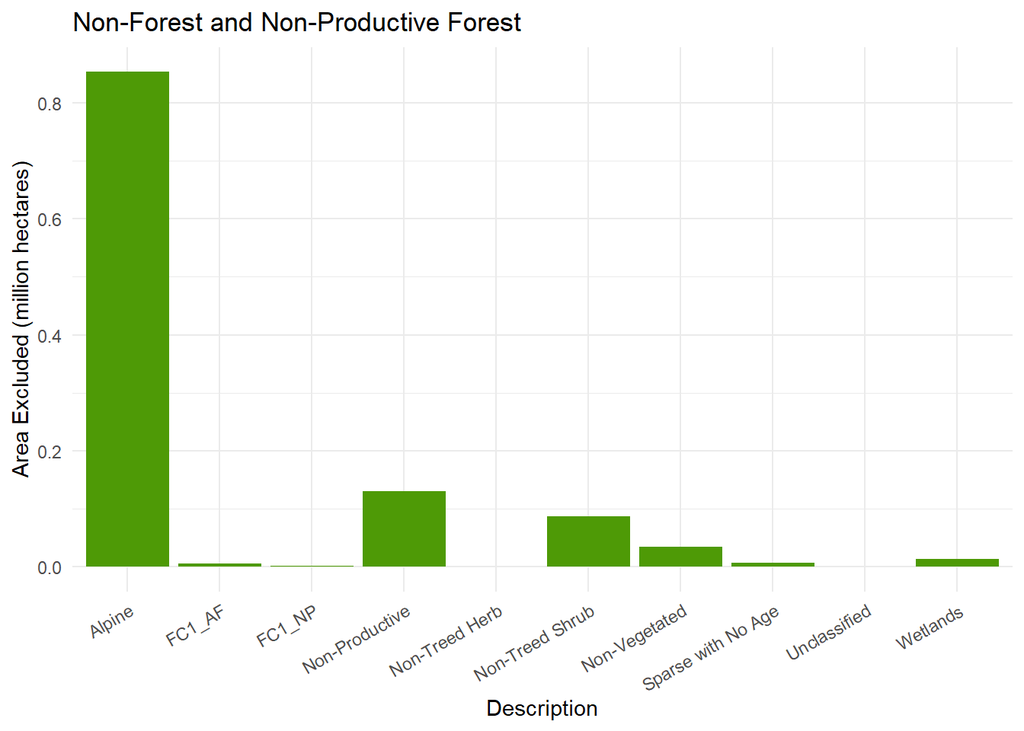

## 2.4 Roads, Trails, Landings and Linear Corridors

Roads were identified using the consolidated road network layer produced for the cumulative effects projects `BC_CE_IntegratedRoads_2017_v1_20170214.gdb\integratedRoadsBuffers_2017`.

The right-of-way layer `WHSE_TANTALIS.TA_CROWN_RIGHTS_OF_WAY_SVW` included large non-linear polygons for unsurveyed future projects. Many of the large polygons contained forested area. This layer was considered inappropriate for use in the netdown.

Owen Fritch noted that `WHSE_TANTALIS.TA_CROWN_RIGHTS_OF_WAY_SVW` is not the authoritative representation, it misses a number of genuine cleared right-of-ways (in particular, large portions of the BC Hydro transmission line to Stewart) and includes a number of abandoned or unconstructed highway sections that are now forested. He recommend using a combination of `WHSE_TANTALIS.TA_SURVEYED_ROW_PARCELS_SVW` and `WHSE_TANTALIS.TA_TRANSPORTATION_SVW` which has the full surveyed Highway right-of-way for Highway 37 and most of Highway 37A to Stewart.

These three road and right-of-way layers were unioned together as one road buffer data source. All the roaded hectares within the TSA were identified with a spatial selection that intersected the road buffer layer with the `tsa43_skey` layer. The road buffer layer was then erased from the `tsa43_skey` selection to produce a layer representing the area outside of road buffers `tsa43_unroaded`.

The percent unroaded was calculated for each hectare. Since each `tsa43_skey` polygon is 1 ha the area remaining after the erase already represents the percentage of the hectare unroaded. The polygon area was selected from the geometry (`st_area(geom)`) and converted from m<sup>2</sup> to ha.

The percent unroaded factor was used to adjust the CFLB to account for the forested area permanently lost due to road right-of-ways.

When a partial netdown is applied to the CFLB factor the THLB remains unchanged since it represents the proportion of the remaining forested area that is harvestable. No CFLB description was added since there is only one partial netdown applied to the CFLB so the source of the reduction is a given.

```sql
update tsa43_netdown set
  p03_road = pct_unroaded
from tsa43_unroaded
where tsa43_unroaded.gr_skey = tsa43_netdown.gr_skey;
```

| Percent Roaded | Total |
| --- | --- |
| <0.05 | 222 |
| 0.1 | 1,495 |
| 0.2 | 3,660 |
| 0.3 | 1,204 |
| 0.4 | 755 |
| 0.5 | 472 |
| 0.6 | 558 |
| 0.7 | 255 |
| 0.8 | 74 |
| 0.9 | 34 |
| 1.0 | 4 |
| Total | 8,733 |

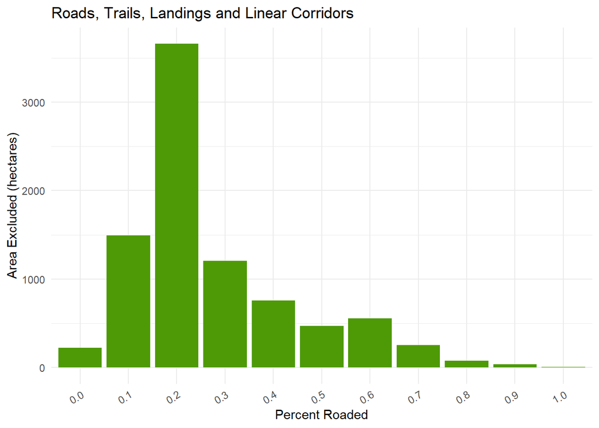

# 3 Crown Forest Land Base

The removals from the CFLB are complete at this point. All following factors are reductions from the THLB.

The area of CFLB was calculated by multiplying the netdown factors. Complete removals were evaluated as a value of zero when a netdown label was present (the ‘is null’ boolean returns ‘FALSE’ and is then cast to the interger zero).

| Crown Forest Land Base | Total | CFLB |
| --- | --- | --- |
| Included | 1,711,705 | 549,689 |

## 3.1 Provincial Parks & Miscellaneous Reserves

The parks and reserves were identified using the ownership layer. The Tantalis layers `WHSE_TANTALIS.TA_PARK_ECORES_PA_SVW` and `WHSE_TANTALIS.TA_CONSERVANCY_AREAS_SVW` were used to confirm all parks and conservancies were excluded.

```sql
update tsa43_netdown set
  n04_park = case
    when own = 60 then 'Conservancy, Ecological Reserve, Protected Area, Provincial Park'
    when own = 63 then 'Biodiversity, Mining, Tourism Area'
    when own = 64 then 'Special Forest Management Area'
  end;
```

| Description | Total | CFLB |
| --- | --- | --- |
| Biodiversity, Mining, Tourism Area | 1,794 | 20 |
| Conservancy, Ecological Reserve, Protected Area, Provincial Park | 34,389 | 21,952 |
| Special Forest Management Area | 65 | 2 |
| Total | 36,248 | 21,974 |

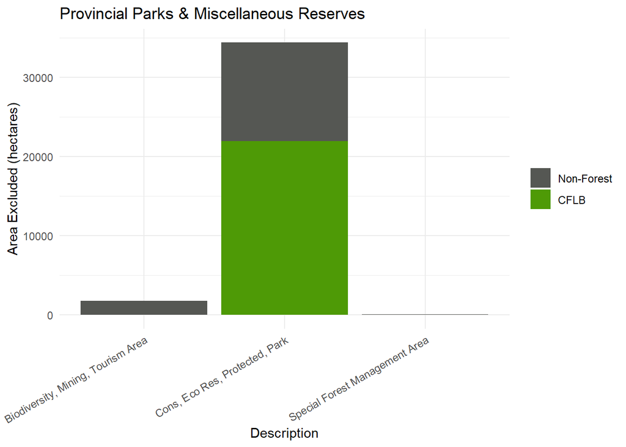

## 3.2 Recreation Sites and Trails

The recreastion sites were excluded from the THLB using the layer `WHSE_FOREST_TENURE.FTEN_RECREATION_POLY_SVW` and two of the remaining ownership codes.

The inclusion of UREP was questioned during the Data Package review. When the district was consulted they found that the UREP around a lake has been removed in the 2019 ownership projection. A protected rec site on the lake better represents current management. The district approved of the other UREP zones representing canoe portages should remain excluded from the THLB. Since the ownership was updated to the 2019 version this correction was made in the final netdown.

The netdown for the Data Package used the attribute `rec_site` (proper names) from the analysis ready GDB but in the analysis ready pg_dump table used for the final netdown only contains the attribute `rec_type` (reserves or sites) so this was used instead. All were classified as rec sites except Kwinageese which is a rec reserve. Since all are removed this distiction is not important. The pg_dump table also includes `rec_status` and `rec_retire` which were used to confirm that all currently active.

```sql
update tsa43_netdown set
  n05_recsite = case
    when rec_type is not null then 'Recreation Site'
    when own = 61 then 'Use, Recreation and Enjoyment of the Public Reserve'
    when own = 68 then 'Forest Recreation Reserves'
  end;
```

| Description | Total | CFLB |
| --- | --- | --- |
| Recreation Site | 70 | 56 |
| Use, Recreation and Enjoyment of the Public Reserve | 1 | 1 |
| Total | 71 | 57 |

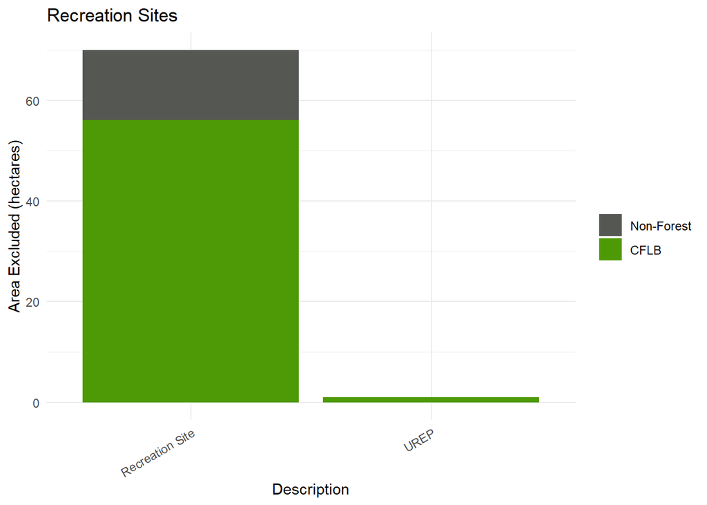

The same process used to calculate an aspatial reduction to the CFLB for road right-of-ways was used to reduce the THLB to account for the buffer than must be protected around trails.

The recreastion trails were identified using the layer `WHSE_FOREST_TENURE.FTEN_RECREATION_LINES_SVW`. A 10 m buffer was applied to the line data. All the hectares that intersected with the trail buffers were selected and the buffers were erased from the `tsa43_skey`. The resulting layer `tsa43_untrailed` represents the area outside of the trail buffers.

```sql
update tsa43_netdown set
  p06_rectrail = pct_untrailed
from tsa43_untrailed
where tsa43_untrailed.gr_skey = tsa43_netdown.gr_skey;
```

| Percent Trailed | Total | CFLB |
| --- | --- | --- |
| <0.05 | 10 | 6 |
| 0.1 | 60 | 35 |
| 0.2 | 239 | 132 |
| 0.3 | 16 | 10 |
| 0.4 | 2 | 2 |
| Total | 326 | 186 |

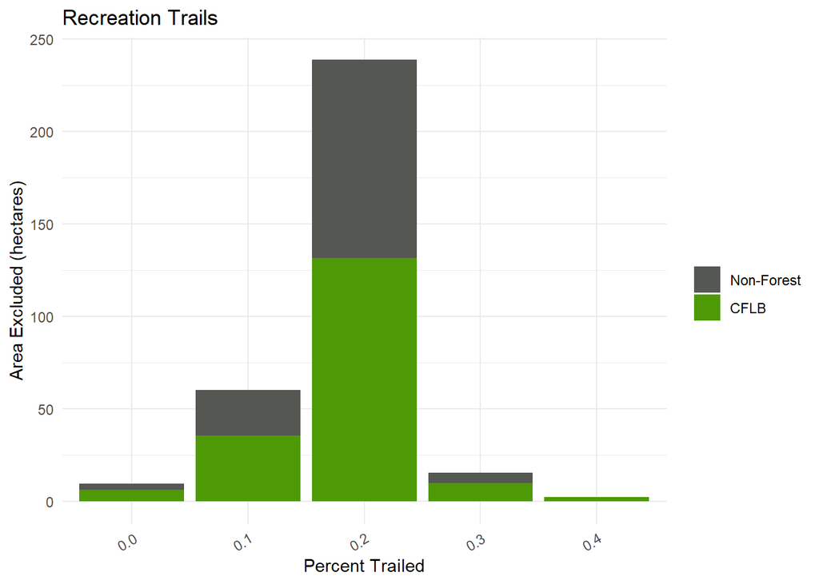

## 3.3 Inoperable Areas

```sql
update tsa43_netdown set
  n07_inoperable = 'Steep Slope'
from tsa43_slope
where
  tsa43_netdown.ogc_fid = tsa43_slope.ogc_fid and
  slope > 60;
```

During Data Package review, it was noted that a small amount of alpine and ESSF parkland was passing through the netdown as forested. These areas are not likely sufficiently forested to be harvestable and have no harvest history so they are removed at this step.

```sql
update tsa43_netdown set
  n07_inoperable = 'Alpine Parkland'
where
  bgc_label in ('CMA un', 'ESSFunp');
```

| Description | Total | CFLB |
| --- | --- | --- |
| Alpine Parkland | 256,272 | 1,026 |
| Steep Slope | 184,662 | 22,075 |
| Total | 440,934 | 23,101 |

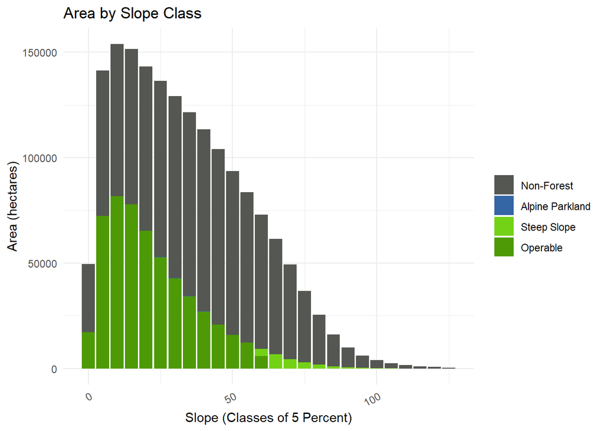

## 3.4 Upper Nass

The Upper Nass was excluded since no major development has occurred or is planned to occur.

```sql
update tsa43_netdown set
  n08_uppernass = 'Upper Nass'
where
  zone_name = 'Upper Nass';
```

| Description | Total | CFLB |
| --- | --- | --- |
| Upper Nass | 452,980 | 141,313 |

## 3.5 Low Timber Growing Potential

All stands with a yield curves were evaluated including some within the non-forest land base.

```sql
update tsa43_netdown set
  n09_lowsite = 'Maximum Volume < 277'
from tsa43_vdyp_stats
where
  maxvol < 277 and
  tsa43_netdown.feature_id = tsa43_vdyp_stats.feat_id;
```

| Description | Total | CFLB |
| --- | --- | --- |
| Maximum Volume < 277 | 315,801 | 178,365 |

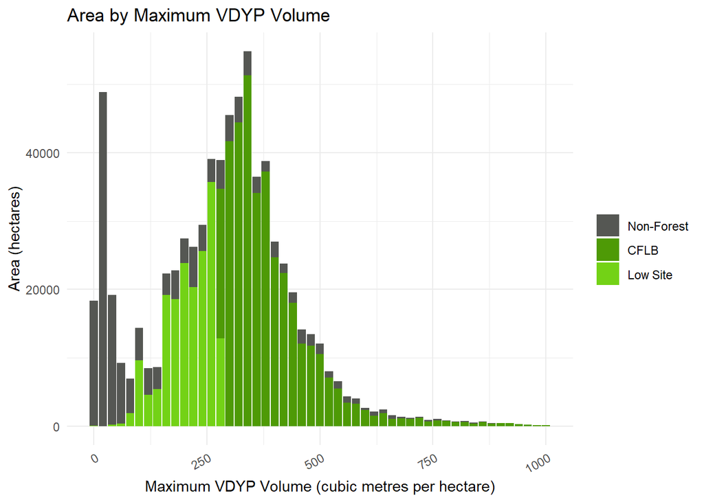

The maximum volume is linked to the site index. Very little area in the TSA exceeds 20 metres site index.

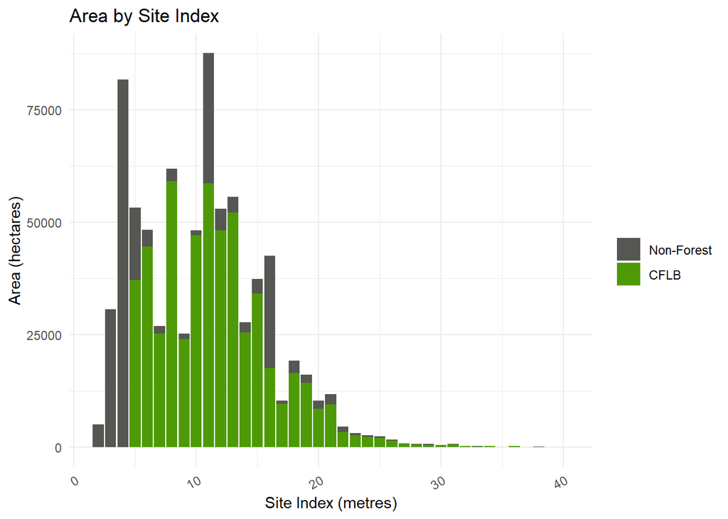

## 3.6 Problem Forest Types

No reductions applied.

## 3.7 Deciduous

All deciduous-leading stands were excluded from the THLB.

```sql
update tsa43_netdown set
  n10_decid = 'Deciduous'
where
  spec_cd_1 in ('EP', 'AT', 'DR', 'ACT', 'E');
```

| Description | Total | CFLB |
| --- | --- | --- |
| ACT | 3 | 3 |
| AT | 2,984 | 1,913 |
| DR | 341 | 304 |
| E | 16 | 16 |
| EP | 2,732 | 2,369 |
| Total | 6,076 | 4,605 |

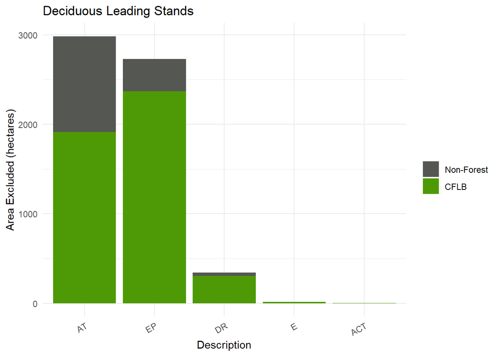

## 3.8 Old Growth Management Areas

All OGMA were excluded from the THLB.

```sql
update tsa43_netdown set
  n11_ogma = 'OGMA'
where
  ogma_provid is not null;
```

| Description | Total | CFLB |
| --- | --- | --- |
| OGMA | 34,739 | 24,764 |

## 3.9 Ecosystem Network

The ecosystem networks established by the SRMP were excluded from the THLB.

The ecosystem network was buffered by 100 metres to create the layer `eco_net_buffer`. Within the buffer only 30% of the forest is accessible as THLB since 70% of the old-forest structure must be retained.

```sql
update tsa43_netdown set
  n12_econet = 'Ecosystem Network',
  p12_econet = 0
where
  eco_network is not null;

update tsa43_netdown set
  n12_econet = 'Ecosystem Network Buffer',
  p12_econet = 0.3
where
  eco_net_buffer is not null;
```

| Description | Total | CFLB |
| --- | --- | --- |
| Ecosystem Network | 47,405 | 23,849 |
| Ecosystem Network Buffer | 12,173 | 8,046 |
| Total | 59,578 | 31,896 |

## 3.10 Stand Level Biodiversity - Wildlife Tree Retention

This factor attempts to account for the area that has been excluded from within the cutblock boundaries in the consolidated cutblocks layer. The area can be assumed to never be logged and will contribute to stand-level biodiversity. It is uncertain if this area adds up to equal the 3.5% reserve reduction that will be applied to all future harvesting in the model. It is a fair representation of past practice and, most importantly, no longer contributes to managed stand yields.

The RESULTS forest cover layer was found to be better than the reserve layer. Entire stands were misclassified as WTRA in the reserve layer. Only very recent harvesting contains mapping of WTP and WTRA in the RESULTS layer. The cutblocks layer has been refined to exclude area within the cutblock boundary that does not support crop trees. The area exclusions were studied and found to correspond with areas classied as non-productive (starting with NP) and non-commercial brush (various forms of NCBR) as well as WTP and WTRA.

The RESULTS layer data never rarely exceeds the cutblock layer boundary so the cutblock layer was used as a mask. The few exceptions could be identified with codes outside the non-productive, non-commercial and WTRA categories. The RESULTS data therefore only shows through the area exclusions within the cutblock boundaries. The RESULTS layer only includes harvesting since 2005 so only reserves established since then will be accounted.

The future reserves are excluded from the THLB by the model at the time of first harvest.

After the Data Package was released the Non-Commercial using lower-case ‘Nc’ was added.

```sql
update tsa43_netdown
  set n13_wtra = case
    when substr(silv_polygon_no,1,2) = 'WT' then 'Wildlife Tree Reserve'
    when substr(silv_polygon_no,1,2) = 'NP' then 'Non-Productive Reserve'
    when substr(silv_polygon_no,1,2) in ('NC','Nc') then 'Non-Commercial Reserve'
  end
where
  harvest_year is null;
```

| Description | Total | CFLB |
| --- | --- | --- |
| Non-Commercial Reserve | 645 | 70 |
| Non-Productive Reserve | 1,436 | 32 |
| Wildlife Tree Reserve | 971 | 908 |
| Total | 3,052 | 1,010 |

## 3.11 Riparian Reserves and Management Areas

The analysis had to resort to using the old aspatial reductions to account for riparian that were produced from a study conducted prior to the 2001 analysis. The TSA was divided into three zones of similar riparian patterns. Unfortunately this zone mapping was not available. The description in the text and the BEC zones listed were used to estimate zones based on grouped landscape units. The BEC mapping was also found to have changed since 2001. The value for the estimated closest BEC zone was applied to the new BEC zones.

```sql
update tsa43_netdown set
  n14_riparian = case
    --Southeast Lower Nass
    when lu_name in ('Sallysout','Madely','Brown Bear','Kinskuch','Tchitin','Kwinamuck','Nass River Kalum') then case
      when bgc_label in ('BAFAun', 'CMA un', 'ESSFun', 'ESSFunp', 'ESSFwv', 'ESSFwvp', 'MH  mm 2', 'MH  mmp')
          then 'Southest 2.8'
      when bgc_label in ('CWH ws 2', 'ICH mc 1', 'ICH mc 1a', 'ICH mc 2', 'ICH vc')
          then 'Southest 3.8'
      when bgc_label in ('SBS mc 2')
          then 'Southest 4.9'
      end
    --Southwest Lower Nass
    when lu_name in ('White','Cambria Icefield','Bear','Tintina','Wildfire','Bowser') then case
      when bgc_label in ('BAFAun', 'CMA un', 'ESSFun', 'ESSFunp', 'ESSFwvp', 'MH  mm 1', 'MH  mm 2', 'MH  mmp')
          then 'Southwest 0.4'
      when bgc_label in ('ICH mc 1')
        then 'Southwest 1.6'
      when bgc_label in ('CWH wm', 'ICH vc')
          then 'Southwest 2.4'
      end
    --Bell Irving
    when lu_name in ('Oweegee','Craven','Muskaboo','Taylor - Damdochax') then case
      when bgc_label in ('BAFAun', 'CMA un', 'ESSFun', 'ESSFunp', 'ESSFwv', 'ESSFwvp', 'MH  mm 2', 'MH  mmp')
          then 'BellIrv 1.4'
      when bgc_label in ('ICH mc 1', 'ICH vc')
          then 'BellIrv 2.7'
      when bgc_label in ('SBS mc 2', 'SBS un')
          then 'BellIrv 4.9'
      end
  end;
```

```sql
update tsa43_netdown set
  p14_riparian = case
    when n14_riparian = 'Southest 2.8' then (1 - 0.028)
    when n14_riparian = 'Southest 3.8' then (1 - 0.038)
    when n14_riparian = 'Southest 4.9' then (1 - 0.049)
    when n14_riparian = 'Southwest 0.4' then (1 - 0.004)
    when n14_riparian = 'Southwest 1.6' then (1 - 0.016)
    when n14_riparian = 'Southwest 2.4' then (1 - 0.024)
    when n14_riparian = 'BellIrv 1.4' then (1 - 0.014)
    when n14_riparian = 'BellIrv 2.7' then (1 - 0.027)
    when n14_riparian = 'BellIrv 4.9' then (1 - 0.049)
    else p14_riparian
  end;
```

### 3.11.1 Kwinageese IRMP

The Kwinageese River was identified using the freshwater atlas `WHSE_BASEMAPPING.FWA_RIVERS_POLY` and `WHSE_BASEMAPPING.FWA_STREAM_NETWORKS_SP`. A definition query identified GNIS name = “Kwinageese River” in both layers. Both layers were buffered by 150m on both sides and then unioned to produce the layer `kwinageese`. A `kwinageese` attribute populated with ‘IRMP Buffer 150m’ was created when the fid was added for rasterization.

```sql
update tsa43_netdown set
  n14_riparian = 'Kwinageese River',
  p14_riparian = 0
where
  kwin_river is not null;
```

| Description | Total | CFLB |
| --- | --- | --- |
| BellIrv 1.4 | 7,678 | 1,489 |
| BellIrv 2.7 | 1,553 | 1,106 |
| BellIrv 4.9 | 1,857 | 1,420 |
| Kwinageese River | 1,670 | 1,191 |
| Southest 2.8 | 6,253 | 1,496 |
| Southest 3.8 | 9,184 | 6,895 |
| Southest 4.9 | 2 | 1 |
| Southwest 0.4 | 1,706 | 112 |
| Southwest 1.6 | 217 | 136 |
| Southwest 2.4 | 3,863 | 2,419 |
| Total | 33,983 | 16,265 |

## 3.12 Water Management Units

All water management units, as defined in the SRMP, were excluded from the THLB.

```sql
update tsa43_netdown set
  n15_watershed = 'Water Management Unit'
where
  water_mu is not null;
```

| Description | unit | Total | CFLB |
| --- | --- | --- | --- |
| Water Management Unit | Bell-Irving | 5,747 | 1,840 |
| Water Management Unit | Kinskuch | 10,679 | 4,337 |
| Water Management Unit | Madely/Kwinageese | 12,842 | 5,776 |
| Water Management Unit | Scrub Lake | 6,372 | 3,401 |
| Total |  | 35,640 | 15,353 |

## 3.13 Wildlife Habitat Areas

The only entry under the `wha_harv_code` was ‘NO HARVEST ZONE’ so this area was excluded from the THLB.

```sql
update tsa43_netdown set
  n16_wha = 'Grizzly Bear'
where
  wha_harv_code is not null;
```

| Description | Total | CFLB |
| --- | --- | --- |
| Grizzly Bear | 60,589 | 24,001 |

## 3.14 Special Habitats for General Wildlife

The only entry under the `wha_harv_code` was ‘NO HARVEST ZONE’ so this area was excluded from the THLB.

```sql
update tsa43_netdown set
  n17_genwild = 'Special Habitats for General Wildlife'
where
  gen_wildlife is not null;
```

| Description | Total | CFLB |
| --- | --- | --- |
| Special Habitats for General Wildlife | 1,075 | 525 |

## 3.15 Archaeological Sites

We no longer have anyone on staff with access to the sensitive data. I found this data in the SRMP working spatial data sets. It was labelled `nass_srmp_arch`.

Owen has provided a more current data set that adds a few additional hectares that will be included in future revisions.

```sql
update tsa43_netdown set
  n18_arch = 'Archaeological Site'
where
  bordennumber is not null;
```

| Description | Total | CFLB |
| --- | --- | --- |
| Archaeological Site | 147 | 75 |

## 3.16 Permanent Sample Plots

Plots are identified by sample_number

```sql
update tsa43_netdown set
  n19_psp = 'Sample Plot'
where
  sample_number is not null;
```

| Description | Total | CFLB |
| --- | --- | --- |
| Sample Plot | 33 | 21 |

## 3.17 Ungulate Winter Range

The spatial data for mountain goat (m-oram) (U-6-002) was all ‘no harvest’ and was excluded from the THLB.

The GWM for moose (m-alal) (U-6-018) states that forage areas should be excluded from harvesting so it was deduced that areas classified as ‘no harvest’ were the forage areas. These were excluded from the THLB. The snow interception GWM will be modelled as a seral retention constraint.

```sql
update tsa43_netdown set
  n21_uwr = 'No Harvest'
where
  uwr_noharvest is not null;
```

| Description | Total | CFLB |
| --- | --- | --- |
| No Harvest | 81,056 | 13,354 |

## 3.18 Pine Mushrooms

Know mushroom area mapping does not exist so estimates were based on research. The ecosystems known to contain a high proportion of pine mushroom potential have partial THLB reductions applied.

Both ICH mc 1 (203720 ha) and ICH mc 1a (21674 ha) were included since they were assumed to be variations of the same ecosystem.

The area removed for pine mushrooms is quite substantial for a partial netdown. During Data Package review, the idea to use a random selection of reserved hectares was proposed. This approach better represents the area reserved and the reserves contribute to biodiversity and other retention objectives.

The seed value is set (at the answer to the meaning of life) to ensure that the random selection doesn’t change each time the netdown is run.

```sql
select setseed(0.42);
update tsa43_netdown set n22_pinemush = 'ICH 6.3% Reserve'
where
  bgc_label in ('ICH mc 1', 'ICH mc 1a') and
  random() < 0.063;

select setseed(0.42);
update tsa43_netdown set n22_pinemush = 'CWH 3.0% Reserve'
where
  bgc_label = 'CWH ws 2' and
  random() < 0.03;
```

| Description | Total | CFLB |
| --- | --- | --- |
| ICH 6.3% Reserve | 14,153 | 11,789 |
| CWH 3.0% Reserve | 1,238 | 390 |
| Total | 15,391 | 12,179 |

# 4 Timber Harvesting Land Base

The removals from the THLB are complete at this point. The final THLB is summarized below.

The area of CFLB was calculated by multiplying the netdown factors. Complete removals were evaluated as a value of zero when a netdown label was present (the ‘is null’ boolean returns ‘FALSE’ and is then cast to the interger zero).

```sql
update tsa43_netdown set thlb_fact =
  (n04_park is null)::int *
  (n05_recsite is null)::int *
  p06_rectrail *
  (n07_inoperable is null)::int *
  (n08_uppernass is null)::int *
  (n09_lowsite is null)::int *
  (n10_decid is null)::int *
  (n11_ogma is null)::int *
  p12_econet *
  (n13_wtra is null)::int *
  p14_riparian *
  (n15_watershed is null)::int *
  (n16_wha is null)::int *
  (n17_genwild is null)::int *
  (n18_arch is null)::int *
  (n19_psp is null)::int *
  (n20_cws is null)::int *
  (n21_uwr is null)::int *
  (n22_pinemush is null)::int;
```

| Timber Harvesting Land Base | Total | CFLB | THLB | Non-THLB |
| --- | --- | --- | --- | --- |
| Included | 1,711,705 | 549,689 | 207,820 | 341,868 |

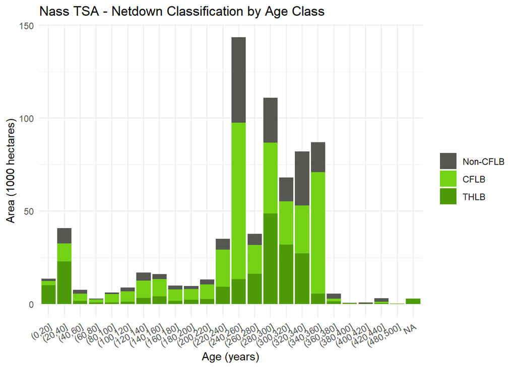

## 4.1 Netdown Table

The final netdown summary table with sequential exclusion totals.

| Netdown Factor | Within gross land base (ha) | Percent of gross (%) | Unique area excluded from THLB (ha) |
| --- | --- | --- | --- |
| TSA boundary | 1,711,705 |  |  |
| Non-provincial Crown Lands | 30,466 | 1.8 | 30,466 |
| Non-Forest and Non-Productive Forest | 1,135,648 | 66.3 | 1,125,110 |
| Roads, Trails, Landings and Linear Corridors | 8,733 | 0.5 | 6,440 |
| Crown forest management land base | 549,689 | 32.1 |  |
| Provincial Parks and Miscellaneous Reserves | 36,248 | 2.1 | 21,974 |
| Recreation Sites | 71 | 0.0 | 22 |
| Recreation Trails | 326 | 0.0 | 184 |
| Inoperable Areas | 440,934 | 25.8 | 23,079 |
| Upper Nass | 452,980 | 26.5 | 135,308 |
| Low Timber Growing Potential | 315,801 | 18.4 | 86,233 |
| Deciduous | 6,076 | 0.4 | 1,481 |
| Old Growth Management Areas | 34,739 | 2.0 | 19,118 |
| Ecosystem Network | 59,578 | 3.5 | 18,975 |
| Wildlife Tree Retention Areas | 3,052 | 0.2 | 843 |
| Riparian Reserves and Management Areas | 33,983 | 2.0 | 7,897 |
| Water Management Units | 35,640 | 2.1 | 7,600 |
| Wildlife Habitat Areas | 60,589 | 3.5 | 11,231 |
| Special Habitats for General Wildlife | 1,075 | 0.1 | 155 |
| Archaeological Sites | 147 | 0.0 | 10 |
| Permanent Sample Plots | 33 | 0.0 | 7 |
| Ungulate Winter Range | 81,056 | 4.7 | 1,537 |
| Pine Mushrooms | 15,391 | 0.9 | 6,213 |
| Timber harvesting land base | 207,820 | 12.1 |  |